# Proyecto Final Fundamentos de Analítica

# Problema

Usted es el encargado de analítica de una empresa de telefonía celular y tiene que proporcionar soluciones para hacer frente a las problemáticas de un sector que ha llegado a saturación del mercado. Tanto su empresa como sus competidores directos tienen que disputarse por una base de clientes limitada, de tal forma que usted tiene que responder a un objetivo estratégico definido por la dirección así:

“Mantener y fidelizar a nuestros clientes por medio de un servicio de calidad que se adapte a sus necesidades particulares.”

Su compañía dispone de una base de datos histórica de personas que hace un año eran clientes propios. Algunos de esos clientes siguen siéndolo hoy en día, otros ya no lo son.

Se han identificado dos proyectos de analítica de datos que permitirán alcanzar tal objetivo, que tendrá que desarrollar en las dos partes siguientes.

## Parte 1

Cree un modelo predictivo de deserción que permita identificar los clientes propensos a irse a las empresas en directa competencia con la suya en el próximo año.

### 1. ¿Encuentra alguna anomalía en los datos? (0.3)

```r
library(ggplot2)
library(caret)
library(corrplot)
library(fpc)
library(cluster)
library(data.table)
library(reshape2)
#library(tidyverse)  # data manipulation
library(factoextra) # clustering algorithms & visualization
```

```r
clientes <- data.frame(read.csv("PF-02-DatosTelco.csv", header = TRUE))
head(clientes)
```

|  | ESTADO | INGRESOS | CASA | PRECIO_DISPOSITIVO | MESES | DURACION | SOBRECARGO | SALDO_RESTANTE | SATISFACCION |
| --- | --- | --- | --- | --- | --- | --- | --- | --- | --- |
| 1 | VINCULADO | 4074840 | 8.830e+08 | 1444153 | 26 | 2.3 | 11.16754 | 20.3 | 1.762872 |
| 2 | VINCULADO | 8574088 | 1.745e+09 | 2157661 | 23 | 3.7 | 0.00000 | 53.5 | 3.361266 |
| 3 | RETIRADO | 795993 | 9.500e+07 | 452809 | 38 | 16.8 | 350.61022 | 13.9 | 8.359438 |
| 4 | RETIRADO | 8115015 | 8.300e+07 | 2617184 | 37 | 17.6 | 230.91389 | 45.7 | 8.964017 |
| 5 | RETIRADO | 8187499 | 6.770e+08 | 666069 | 19 | 0.0 | 131.54198 | 67.2 | 8.808206 |
| 6 | VINCULADO | 7250225 | 4.240e+08 | 548116 | 19 | 2.2 | 0.00000 | 72.0 | 1.979549 |

Vamos a analizar entonces las variables numéricas para evaluar que tipo de preprocesamientos debemos hacer para no influenciar de manera inadecuada los análisis que realizaremos.

```r
str(clientes)
```

```
'data.frame':   23162 obs. of  9 variables:
 $ ESTADO            : Factor w/ 2 levels "RETIRADO","VINCULADO": 2 2 1 1 1 2 1 1 2 1 ...
 $ INGRESOS          : int  4074840 8574088 795993 8115015 8187499 7250225 7256758 3262245 7281977 874177 ...
 $ CASA              : num  8.83e+08 1.74e+09 9.50e+07 8.30e+07 6.77e+08 ...
 $ PRECIO_DISPOSITIVO: num  1444153 2157661 452809 2617184 666069 ...
 $ MESES             : int  26 23 38 37 19 19 20 32 41 19 ...
 $ DURACION          : num  2.3 3.7 16.8 17.6 0 2.2 14.8 1.3 3 17.8 ...
 $ SOBRECARGO        : num  11.2 0 350.6 230.9 131.5 ...
 $ SALDO_RESTANTE    : num  20.3 53.5 13.9 45.7 67.2 72 69.5 19 64.6 19.9 ...
 $ SATISFACCION      : num  1.76 3.36 8.36 8.96 8.81 ...
```

```r
summary(clientes)
```

```
       ESTADO         INGRESOS            CASA           PRECIO_DISPOSITIVO     MESES         DURACION       SOBRECARGO
 RETIRADO :11665   Min.   : 150000   Min.   :8.000e+07   Min.   : 200000    Min.   : 0.0   Min.   : 0.00   Min.   :  0.00
 VINCULADO:11497   1st Qu.:2156296   1st Qu.:3.570e+08   1st Qu.: 657184    1st Qu.:14.0   1st Qu.: 2.10   1st Qu.: 12.57
                   Median :6137553   Median :6.240e+08   Median :1237456    Median :24.0   Median :14.60   Median : 75.38
                   Mean   :4813115   Mean   :7.161e+08   Mean   :1315340    Mean   :24.2   Mean   : 9.61   Mean   :110.06
                   3rd Qu.:7347180   3rd Qu.:9.078e+08   3rd Qu.:1829581    3rd Qu.:34.0   3rd Qu.:16.10   3rd Qu.:201.55
                   Max.   :9650000   Max.   :2.180e+09   Max.   :4700000    Max.   :79.0   Max.   :20.10   Max.   :411.17
 SALDO_RESTANTE    SATISFACCION
 Min.   :  0.00   Min.   :0.6136
 1st Qu.: 15.20   1st Qu.:2.7055
 Median : 37.65   Median :4.0645
 Mean   : 42.99   Mean   :5.4808
 3rd Qu.: 70.00   3rd Qu.:8.2682
 Max.   :130.70   Max.   :9.6426
```

```r
apply(clientes[, -c(1)], 2, mean)
```

```
          INGRESOS               CASA PRECIO_DISPOSITIVO              MESES           DURACION         SOBRECARGO
      4.813115e+06       7.161435e+08       1.315340e+06       2.419713e+01       9.609852e+00       1.100563e+02
    SALDO_RESTANTE       SATISFACCION
      4.299189e+01       5.480840e+00
```

```r
apply(clientes[, -c(1)], 2, var)
```

```
          INGRESOS               CASA PRECIO_DISPOSITIVO              MESES           DURACION         SOBRECARGO
      7.493216e+12       2.315103e+17       5.603571e+11       2.034621e+02       4.956170e+01       1.015490e+04
    SALDO_RESTANTE       SATISFACCION
      9.123142e+02       7.895749e+00
```

Podemos ver que las variables tienen promedios muy diferentes, que impedirán a los algoritmos de clustering (basados en distancia) encontrar estructuras adecuadas. Además, podemos ver también que las varianzas son muy diferentes, lo que influenciaría negativamente la búsqueda de los componente principales de PCA, que se basa en la dispersión de los datos. Vamos entonces a estandarizar los datos para arreglar estos problemas.

```r
modelo_std<- preProcess(clientes, method = c("center", "scale"))
clientes_std <- predict(modelo_std, clientes)
head(clientes_std)
```

|  | ESTADO | INGRESOS | CASA | PRECIO_DISPOSITIVO | MESES | DURACION | SOBRECARGO | SALDO_RESTANTE | SATISFACCION |
| --- | --- | --- | --- | --- | --- | --- | --- | --- | --- |
| 1 | VINCULADO | -0.2697020 | 0.3467831 | 0.1720785 | 0.12639266 | -1.0383302 | -0.9813166 | -0.75127407 | -1.3231496 |
| 2 | VINCULADO | 1.3739346 | 2.1383052 | 1.1252398 | -0.08392681 | -0.8394668 | -1.0921371 | 0.34789844 | -0.7543133 |
| 3 | RETIRADO | -1.4675095 | -1.2909423 | -1.1522384 | 0.96767055 | 1.0213267 | 2.3871226 | -0.96316275 | 1.0244348 |
| 4 | RETIRADO | 1.2062290 | -1.3158823 | 1.7391076 | 0.89756406 | 1.1349630 | 1.1993231 | 0.08965912 | 1.2395924 |
| 5 | RETIRADO | 1.2327083 | -0.0813532 | -0.8673486 | -0.36435277 | -1.3650344 | 0.2132119 | 0.80147264 | 1.1841426 |
| 6 | VINCULADO | 0.8903094 | -0.6071712 | -1.0249197 | -0.36435277 | -1.0525348 | -1.0921371 | 0.96038915 | -1.2460385 |

```
non-vector columns will be ignored
```

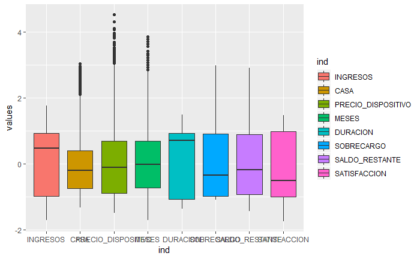

```r
ggplot(stack(clientes_std), aes(x = ind, y = values)) + geom_boxplot(aes(fill=ind))
```

Podemos ver que en las variables CASA, PRECIO_DISPOSITIVO y MESES presentan valores atipicios. Pero estos valores atipicos pueden estar fuertemente correlacionados con la posibilidad de que sea un cliente satisfecho con el servicio, pues el consumira el mejor paquete de servicio.

### 2. La empresa considera que los valores de variables que estén a más de 4 desviaciones estándar del promedio deberían ser consideradas excepcionales, y por lo tanto no se deben considerar en los análisis. Identifíquelas y apártelas del dataset (0.3)

Como todos los datos estan estandarizados, su varianza es 1:

```r
apply(clientes_std[, -c(1)], 2, var)
```

```
          INGRESOS               CASA PRECIO_DISPOSITIVO              MESES           DURACION         SOBRECARGO
                 1                  1                  1                  1                  1                  1
    SALDO_RESTANTE       SATISFACCION
                 1                  1
```

Calculamos la desviacion de los datos estandarizados:

```r
means = apply(clientes_std[, -c(1)], 2, mean)
means
```

```
          INGRESOS               CASA PRECIO_DISPOSITIVO              MESES           DURACION         SOBRECARGO
     -1.103904e-16       2.199595e-18      -1.232378e-16      -1.254673e-16       9.125020e-18       3.732389e-17
    SALDO_RESTANTE       SATISFACCION
     -2.641218e-17      -8.531556e-17
```

Para encontrar los outliers basta con saber cuales superan de maginutud 4 veces la media de cada variable, esto es posible porque como los datos normalizados tienen un varianza de 1, por tanto la media +- desv*4 => media +- raiz(1)*4 => media +- 4.

```r
indicesAQuitarNuevos <- which( abs(clientes_std$PRECIO_DISPOSITIVO) > means["PRECIO_DISPOSITIVO"] + 4)
clientes_std[indicesAQuitarNuevos,]
```

|  | ESTADO | INGRESOS | CASA | PRECIO_DISPOSITIVO | MESES | DURACION | SOBRECARGO | SALDO_RESTANTE | SATISFACCION |
| --- | --- | --- | --- | --- | --- | --- | --- | --- | --- |
| 8004 | VINCULADO | -0.4743394 | 0.38419312 | 4.296721 | -1.626270 | -1.0667393 | -1.0921371 | -0.7678279 | -0.9746027 |
| 18019 | VINCULADO | -0.5152238 | 0.73335287 | 4.109098 | 1.107884 | -0.7826487 | -0.9258750 | -0.4201980 | -1.1851561 |
| 18690 | VINCULADO | 1.3996362 | 2.21104678 | 4.521501 | 2.650226 | -1.2656027 | -1.0452898 | 1.1888316 | -0.8897756 |
| 21450 | RETIRADO | -0.6406627 | 0.01632839 | 4.061703 | 1.318203 | -0.9673076 | -0.1050539 | -0.5625607 | 0.9336297 |

Puede que un cliente sea excepcional en varias variables, por lo que no queremos eliminar de nuestro análisis más clientes de lo necesario. Vamos a analizar entonces variable por variable los clientes excepcionales y a guardar sus índices en el dataframe progresivamente, para poder eliminarlos al final.

```r
indicesAQuitar <- NULL
indicesAQuitar <- union(indicesAQuitar, indicesAQuitarNuevos)

indicesAQuitarNuevos <- which( abs(clientes_std$INGRESOS) > means["INGRESOS"] + 4)
indicesAQuitar <- union(indicesAQuitar, indicesAQuitarNuevos)


indicesAQuitarNuevos <- which( abs(clientes_std$CASA) > means["CASA"] + 4)
indicesAQuitar <- union(indicesAQuitar, indicesAQuitarNuevos)

indicesAQuitarNuevos <- which( abs(clientes_std$MESES)> means["MESES"] + 4)

indicesAQuitar <- union(indicesAQuitar, indicesAQuitarNuevos)
indicesAQuitarNuevos <- which( abs(clientes_std$DURACION) > means["DURACION"] + 4)

indicesAQuitar <- union(indicesAQuitar, indicesAQuitarNuevos)
indicesAQuitarNuevos <- which( abs(clientes_std$SOBRECARGO) > means["SOBRECARGO"] + 4)

indicesAQuitar <- union(indicesAQuitar, indicesAQuitarNuevos)
indicesAQuitarNuevos <- which( abs(clientes_std$SALDO_RESTANTE) > means["SALDO_RESTANTE"] + 4)

indicesAQuitar <- union(indicesAQuitar, indicesAQuitarNuevos)
indicesAQuitarNuevos <- which( abs(clientes_std$SATISFACCION) > means["SATISFACCION"] + 4)

indicesAQuitar <- union(indicesAQuitar, indicesAQuitarNuevos)

length(indicesAQuitar)
```

```
[1] 4
```

Hay en total 4 clientes que serán ignorados por el análisis, todos atipicios en la variable PRECIO_DISPOSITIVO:

```r
clientes_std = clientes_std[-indicesAQuitar,]
```

### 3. Analice la correlación entre las variables y explique lo que puede implicar desde el punto de vista de PCA. (0.2)

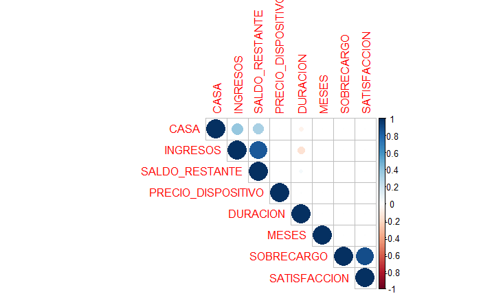

```r
corMat <- cor(clientes_std[, -c(1)])
corrplot(corMat, type="upper", order="hclust")
```

Se ve una fuere correlacion entre SOBRECARGO-SATISFACCION, INGRESOS-SALDO_RESTANTE Una correlacion moderada entre CASA-INGRESOS-SALDO_RESTANTE Una correlacion debile entre INGRESOS-DURACION

### 4. Debe entrenar 3 tipos de modelos predictivos de diferentes familias:

#### a. Defina el protocolo de evaluación que va a utilizar para calibrar los modelos y estimar la calidad del modelo final. (0.3)

Vamos a particionar aleatoriamente “a mano” el dataset, sacando una muestra aleatoria del 75% de los datos (17369 registros) para el entrenamiento y el resto para el test con la función createDataPartition de Caret. Inicializamos el generador aleatorio para poder garantizar reproducibilidad.

```r
set.seed(3456)
trainIndex <- createDataPartition(clientes[-indicesAQuitar,]$ESTADO, p = .75, list = FALSE, times = 1)

train <- clientes[ trainIndex,]
test <-  clientes[-trainIndex,]
```

El protocolo de evaluacion del modelo va a ser repeated K-Fold cross-validation

```r
cctrl <- trainControl(method="repeatedcv",
                      repeats=5,
                      number=5,
                      summaryFunction = twoClassSummary,
                      classProbs = TRUE )
```

#### b. Establezca las métricas que va a utilizar, justificando su escogencia (0.2)

Queremos identificar los clientes mas propensos a irse a la competencia directa de la empresa, por tanto es mas costoso decir que el cliente permanece VINCULADO cuando en realidad se RETIRA que decir que el cliente se RETIRA cuando permanece VINCULADO.

#### c. Calibre 3 tipos de modelos diferentes: K-NN, árbol de decisión y algún otro que propongan, utilizando las métricas y protocolo definido (1.0)

```r
library(MASS)
```

Modelo KNN

```r
model_knn <- train(ESTADO ~., data = train,
                     method = "knn",
                     trControl = cctrl,
                     preProcess=c("center", "scale"),
                     tuneGrid=expand.grid(k=c(15, 25, 35, 45, 55, 65, 75, 85)),
                     metric="Spec")
model_knn
```

```
k-Nearest Neighbors

17369 samples
    8 predictor
    2 classes: 'RETIRADO', 'VINCULADO'

Pre-processing: centered (8), scaled (8)
Resampling: Cross-Validated (5 fold, repeated 5 times)
Summary of sample sizes: 13895, 13895, 13895, 13895, 13896, 13895, ...
Resampling results across tuning parameters:

  k   ROC        Sens       Spec
  15  0.9058283  0.9042735  0.9105196
  25  0.9055316  0.9042735  0.9105196
  35  0.9046230  0.9042735  0.9105196
  45  0.9039200  0.9042735  0.9105196
  55  0.9038964  0.9042735  0.9105196
  65  0.9037523  0.9042735  0.9105196
  75  0.9042757  0.9042735  0.9105196
  85  0.9042726  0.9042735  0.9105196

Spec was used to select the optimal model using the largest value.
The final value used for the model was k = 85.
```

Modelo 2

```r
model_rpart <- train(ESTADO ~., data = train,
                     method = "rpart",
                     trControl = cctrl,
                     preProcess=c("center", "scale"),
                     metric="Spec")
model_rpart
```

```
CART

17369 samples
    8 predictor
    2 classes: 'RETIRADO', 'VINCULADO'

Pre-processing: centered (8), scaled (8)
Resampling: Cross-Validated (5 fold, repeated 5 times)
Summary of sample sizes: 13895, 13895, 13895, 13895, 13896, 13895, ...
Resampling results across tuning parameters:

  cp            ROC        Sens       Spec
  6.981615e-05  0.9061302  0.8970484  0.8984414
  9.308820e-05  0.9060767  0.9005128  0.9049110
  8.127764e-01  0.7102820  0.9477835  0.4727805

Spec was used to select the optimal model using the largest value.
The final value used for the model was cp = 9.30882e-05.
```

Modelo regresión logística

```r
model_glm <- train(ESTADO ~., data = train,
                   method = "glmStepAIC",
                   trControl = cctrl,
                   preProcess=c("center", "scale"),
                   metric="Spec")
```

```
Start:  AIC=8678.72
.outcome ~ INGRESOS + CASA + PRECIO_DISPOSITIVO + MESES + DURACION +
    SOBRECARGO + SALDO_RESTANTE + SATISFACCION

                     Df Deviance     AIC
- CASA                1   8660.7  8676.7
- PRECIO_DISPOSITIVO  1   8661.0  8677.0
- MESES               1   8661.1  8677.1
- DURACION            1   8661.6  8677.6
- SALDO_RESTANTE      1   8662.3  8678.3
<none>                    8660.7  8678.7
- INGRESOS            1   8664.1  8680.1
- SOBRECARGO          1   8680.4  8696.4
- SATISFACCION        1   9995.2 10011.2

Step:  AIC=8676.72
.outcome ~ INGRESOS + PRECIO_DISPOSITIVO + MESES + DURACION +
    SOBRECARGO + SALDO_RESTANTE + SATISFACCION

                     Df Deviance     AIC
- PRECIO_DISPOSITIVO  1   8661.0  8675.0
- MESES               1   8661.1  8675.1
- DURACION            1   8661.6  8675.6
- SALDO_RESTANTE      1   8662.4  8676.4
<none>                    8660.7  8676.7
- INGRESOS            1   8664.3  8678.3
- SOBRECARGO          1   8680.4  8694.4
- SATISFACCION        1   9995.3 10009.3

Step:  AIC=8675.02
.outcome ~ INGRESOS + MESES + DURACION + SOBRECARGO + SALDO_RESTANTE +
    SATISFACCION

                 Df Deviance     AIC
- MESES           1   8661.4  8673.4
- DURACION        1   8661.9  8673.9
- SALDO_RESTANTE  1   8662.7  8674.7
<none>                8661.0  8675.0
- INGRESOS        1   8664.6  8676.6
- SOBRECARGO      1   8680.6  8692.6
```

[output cut: 1935 more lines]

```
.outcome ~ INGRESOS + SOBRECARGO + SATISFACCION

               Df Deviance   AIC
- INGRESOS      1    10905 10911
<none>               10903 10911
- SOBRECARGO    1    10924 10930
- SATISFACCION  1    12598 12604

Step:  AIC=10910.76
.outcome ~ SOBRECARGO + SATISFACCION

               Df Deviance   AIC
<none>               10905 10911
- SOBRECARGO    1    10926 10930
- SATISFACCION  1    12598 12602
```

```r
model_glm
```

```
Generalized Linear Model with Stepwise Feature Selection

17369 samples
    8 predictor
    2 classes: 'RETIRADO', 'VINCULADO'

Pre-processing: centered (8), scaled (8)
Resampling: Cross-Validated (5 fold, repeated 5 times)
Summary of sample sizes: 13895, 13896, 13895, 13895, 13895, 13895, ...
Resampling results:

  ROC        Sens       Spec
  0.9065998  0.9042735  0.9105192
```

#### d. Evalúe los 3 modelos encontrados, escoja el mejor, explicando y concluyendo lo que encontró, utilizando las métricas y protocolo definido (0.5)

Modelo KNN

```r
predictions_knn<-predict(object=model_knn, test)
confusionMatrix(predictions_knn, test$ESTADO)
```

```
Confusion Matrix and Statistics

           Reference
Prediction  RETIRADO VINCULADO
  RETIRADO      2577       259
  VINCULADO      313      2644

               Accuracy : 0.9013
                 95% CI : (0.8933, 0.9088)
    No Information Rate : 0.5011
    P-Value [Acc > NIR] : < 2e-16

                  Kappa : 0.8025

 Mcnemar's Test P-Value : 0.02669

            Sensitivity : 0.8917
            Specificity : 0.9108
         Pos Pred Value : 0.9087
         Neg Pred Value : 0.8941
             Prevalence : 0.4989
         Detection Rate : 0.4448
   Detection Prevalence : 0.4896
      Balanced Accuracy : 0.9012

       'Positive' Class : RETIRADO
```

Modelo arbol de desicion

```r
predictions_rpart<-predict(object=model_rpart, test)
confusionMatrix(predictions_rpart, test$ESTADO)
```

```
Confusion Matrix and Statistics

           Reference
Prediction  RETIRADO VINCULADO
  RETIRADO      2577       259
  VINCULADO      313      2644

               Accuracy : 0.9013
                 95% CI : (0.8933, 0.9088)
    No Information Rate : 0.5011
    P-Value [Acc > NIR] : < 2e-16

                  Kappa : 0.8025

 Mcnemar's Test P-Value : 0.02669

            Sensitivity : 0.8917
            Specificity : 0.9108
         Pos Pred Value : 0.9087
         Neg Pred Value : 0.8941
             Prevalence : 0.4989
         Detection Rate : 0.4448
   Detection Prevalence : 0.4896
      Balanced Accuracy : 0.9012

       'Positive' Class : RETIRADO
```

Modelo regresion logistica

```r
predictions_glm<-predict(object=model_glm, test)
confusionMatrix(predictions_glm, test$ESTADO)
```

```
Confusion Matrix and Statistics

           Reference
Prediction  RETIRADO VINCULADO
  RETIRADO      2577       259
  VINCULADO      313      2644

               Accuracy : 0.9013
                 95% CI : (0.8933, 0.9088)
    No Information Rate : 0.5011
    P-Value [Acc > NIR] : < 2e-16

                  Kappa : 0.8025

 Mcnemar's Test P-Value : 0.02669

            Sensitivity : 0.8917
            Specificity : 0.9108
         Pos Pred Value : 0.9087
         Neg Pred Value : 0.8941
             Prevalence : 0.4989
         Detection Rate : 0.4448
   Detection Prevalence : 0.4896
      Balanced Accuracy : 0.9012

       'Positive' Class : RETIRADO
```

Los 3 modelos tienen resultados similares tanto en especifidad como en Accuracy y Kappa. Por velocidad en entraneamiento, evaluacion, recalibracion automatica escogemos el modelo de regresion logistica como el mas adecuado.

## Parte 2

Analice los clientes que se han ido, creando un modelo de segmentación de los clientes que desertan la compañía, teniendo en cuenta sus datos socio-demográficos y comportamientos de consumo del servicio de telefonía. Interpretar el perfil de clientes asignado a cada segmento, caracterizándolos de tal manera que le permita sugerir 3 a 5 campañas de fidelización.

### 1. Definicion del numero de campañas a realizar (0.6)

Extraemos los clientes retirados del dataset y removemos la columna de estado puesto que no nos interesa para nuestro analisis

```r
retirados = clientes[-c(indicesAQuitar), ][which(clientes$ESTADO == "RETIRADO"), -c(1)]
retirados
```

|  | INGRESOS | CASA | PRECIO_DISPOSITIVO | MESES | DURACION | SOBRECARGO | SALDO_RESTANTE | SATISFACCION |
| --- | --- | --- | --- | --- | --- | --- | --- | --- |
| 3 | 795993 | 9.500e+07 | 452809 | 38 | 16.8 | 350.610224 | 13.9 | 8.359438 |
| 4 | 8115015 | 8.300e+07 | 2617184 | 37 | 17.6 | 230.913888 | 45.7 | 8.964017 |
| 5 | 8187499 | 6.770e+08 | 666069 | 19 | 0.0 | 131.541983 | 67.2 | 8.808206 |
| 7 | 7256758 | 7.120e+08 | 3493707 | 20 | 14.8 | 217.322554 | 69.5 | 8.285137 |
| 8 | 3262245 | 6.840e+08 | 985708 | 32 | 1.3 | 275.595131 | 19.0 | 8.040629 |
| 10 | 874177 | 7.250e+08 | 1403586 | 19 | 17.8 | 0.000000 | 19.9 | 2.138861 |
| 11 | 4061667 | 9.340e+08 | 438256 | 9 | 1.8 | 0.000000 | 4.9 | 2.164890 |
| 12 | 3529836 | 7.240e+08 | 647659 | 18 | 4.3 | 303.162095 | 29.6 | 7.984475 |
| 13 | 3829846 | 8.770e+08 | 1150132 | 40 | 5.4 | 150.868408 | 33.2 | 7.855744 |
| 14 | 7639749 | 3.170e+08 | 825889 | 27 | 0.7 | 178.247186 | 89.5 | 7.826984 |

[output cut: 990 more lines]

### 2. Extraiga los componentes principales, analice sus niveles de varianza explicada, e interprete los 3 más importantes en función de las variables originales. (0.6)

Para extraer los componentes principales vamos a utilizar los datos normalizados, porque la tecnica PCA se ve afectada por la distancia. Ademas vamos a quitar la columna que indica si se encuentra vinculado o no. Por lo tanto el resultado de extraer los componentes principales es:

```r
clientes_std$ESTADO <- NULL # Eliminamos la columna que indica si se encuentra vinculado o no
pcomp <- prcomp(clientes_std, scale=TRUE)
```

Ahora vamoa analizar la varianza de los componenetes principales que entrego el analisis.

```r
varianzasPC <- pcomp$sdev^2
varianzasPC
```

```
[1] 2.0887590 1.8897206 1.0243107 1.0013653 0.9927975 0.7636286 0.1292723 0.1101460
```

```r
totalPC <- sum(varianzasPC)
porcentajeInfoPC <- varianzasPC / sum(varianzasPC)
porcentajeInfoPC
```

```
[1] 0.26109487 0.23621508 0.12803884 0.12517067 0.12409968 0.09545357 0.01615904 0.01376824
```

```r
print("cantidad de componentes principales")
```

```
[1] "cantidad de componentes principales"
```

```r
totalPC
```

```
[1] 8
```

Como podemos observar salen 8 componentes principales que a su vez representan la informacion de la siguiente forma:

```r
dfPorcentajes = data.frame(PC=1:8, simple=porcentajeInfoPC, acumulado=cumsum(porcentajeInfoPC))
dfPorcentajes
```

| PC | simple | acumulado |
| --- | --- | --- |
| 1 | 0.26109487 | 0.2610949 |
| 2 | 0.23621508 | 0.4973100 |
| 3 | 0.12803884 | 0.6253488 |
| 4 | 0.12517067 | 0.7505195 |
| 5 | 0.12409968 | 0.8746191 |
| 6 | 0.09545357 | 0.9700727 |
| 7 | 0.01615904 | 0.9862318 |
| 8 | 0.01376824 | 1.0000000 |

Como podemos ver solo hasta el quinto componente principal podemos decir que la informacion se representa en un 87.5%, lo cual indica que las variables no estan muy correlacionadas entre si.

### 3. Compare de los clusters obtenidos utilizando K-Means y Clustering jerárquico, seleccionando los resultados de uno de los dos métodos. Justifique. (0.4)

### K-Means

Este es el proceso para obtener los cluster con K-Means

```r
k <- 3
set.seed(1234)
kmClustering3 <- kmeans(clientes_std, k, nstart=100, iter.max=150)
```

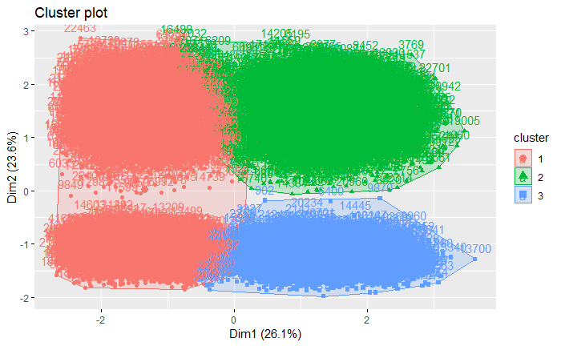

```r
fviz_cluster(kmClustering3, data = clientes_std)
```